# 工学を専門とする大学生の英語学習に対する動機づけの調査

Published: 2023-12-8; Last Update (JST) 2023-12-15 13:39:23.426952

## 背景

- 学期開始時の習熟度だけでなく、動機付けも含めたクラス編成の必要性

```
    -   「英語が苦手だけど、やる気がある学生」-> 初級者クラス？

    -   「英語の成績が良いけど、やる気があまりない学生」-> 上級者クラス？
```

## 研究の目的

- 第一段階：動機付けの実態調査（本研究）
  - 先行研究で提案された質問紙の適切性の再検討（Agawa & Takeuchi, 2016）
  - 学習者の動機づけの傾向把握（e.g., Saito et al., 2017）
- 第二段階：動機づけと習熟度の関係調査（今後）
  - 学期開始時、学期中、学期末での動機づけの変容調査（e.g., Wang et al., 2023）
  - 各時点での動機づけと英語成績との関係調査（e.g., Alamer & Alrabai, 2023）

## 先行研究

## 自己決定理論

- 行動に対する自律性（自己決定性）の程度が、その行動の成果に影響を及ぼすと言う動機づけの理論（Deci & Ryan, 2011）
- 自己決定理論を構成する6つのミニ理論（Ryan & Deci, 2017）
  - 認知的評価理論
  - 有機的統合理論
  - 因果志向性理論
  - 基本的心理欲求理論
  - 目標内容理論
  - Relationships Motivation Theory
- ミニ理論によって、動機づけの分類の枠組みが異なる
  - 有機的統合理論：内発的動機づけ、外発的動機づけ、無動機（e.g., Agawa & Takeuchi, 2016）
  - 因果志向性理論：自律的動機づけ、統制的動機づけ（e.g., Alamer & Alrabai, 2023）

## 有機的統合理論における動機づけの枠組み

- 内発的動機づけ：内なる感情によって動機づけられること
  - 行動そのものに感じる喜びや満足など
  - 「英語に接すること自体が好きなので勉強する」
- 外発的動機づけ：外部からの統制によって動機づけられること
  - 「他者の期待に応えること」「試験で良い成績を取ること」「良い職業に就くこと」など
  - 「いろいろな場面で英語は役に立つと思うから勉強している」
  - 「単位を取るために仕方なく英語を勉強している」
- 無動機：行動を起こす動機がない状態
  - 「とにかく英語の勉強はもうしたくない」

## 有機的統合理論における動機づけの枠組み（2）

- 「内発的動機づけ」「外発的動機づけ」「無動機」は、別々の独立した概念ではなく、段階のあるものとして、連続線上に位置付けられる（Deci & Ryan, 2008）

[figure not shown]

## Agawa and Takeuchi (2016)

- 廣森 (2006)で開発された質問紙の再検証
  - 日本人英語学習者の動機づけを測定する質問紙を開発
- 2つの部分からなる
  - 心理的欲求
    - 自律性
    - 有能感
    - 関係性
  - 動機付けの種類
    - 内発的動機付け
    - 外発的動機付け
      - 統合的
      - 同一化 + 取り入れ的
      - 外発的
    - 無動機

## Agawa and Takeuchi (2017)

- Agawa and Takeuchi (2016)で開発された質問紙の妥当性を検証
  - 444名 (日本人EFL学習者)
    - 専攻 ：経済、文学、薬学、理工、情報など
    - 偏差値：低（- 50）、中（51 - 62）、高（63 - ）
- 確証的因子分析
  - Agawa and Takeuchi (2016)で提唱された動機づけのモデルと高い適合度を示した
    - 妥当性確認

## 研究課題

### R.Q. 1：提案された質問紙の適切性の再検討

- 因子数と因子構造が先行研究の報告と一致するか

### R.Q. 2：学習者の動機づけの傾向はどうか

- 外発的動機付けと内発的動機付けのどちらが高いか

## 本研究

## 調査対象者

- 工学を専門とする単科大学の学生125名
- 2023年度後期の第一回目の講義でアンケートを配布
  - 必修科目（*n* = 89）
  - 選択科目（*n* = 36）
- Google Formで作成したアンケートを講義の担当者が実施
  - データ使用に許可をした学生のデータのみを分析に使用

## 信頼性係数（クロンバックの *α* と95%CI）

| raw | lower | upper |
| --- | --- | --- |
| 0.91 | 0.88 | 0.93 |

## 探索的因子分析

### 事前の確認

- KM0によるサンプリングの適切性指標

| MSA |
| --- |
| 0.88 |

- Bartlettの球面性検定による質問紙項目間の相関
  - 質問紙項目間に相関がある
- 並行分析（抽出する因子数の決定）

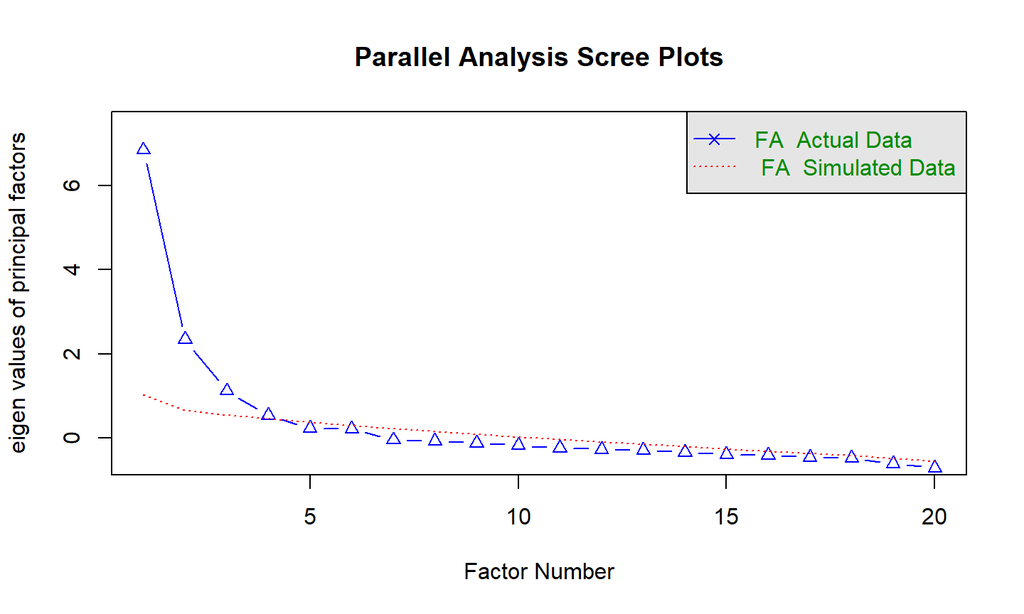

```
## Parallel analysis suggests that the number of factors =  4  and the number of components =  NA
```

## 結果

- 因子の推定法
  - 最尤法、プロマックス回転
  - 因子負荷が.40より小さい項目は削除
    - 削除した項目はなし

Factor Analysis

|  | Factor 1 | Factor 2 | Factor 3 | Factor 4 |
| --- | --- | --- | --- | --- |
| 私が英語を学ぶのは、英語が話されているのを聞くのが心地よいからだ。 | 0.99 | -0.13 | 0.03 | 0.15 |
| 私が英語を学ぶのは、英語を話していると気持ちがよいからだ。 | 0.99 | -0.14 | 0.02 | 0.12 |
| 英語を学ぶことに刺激を感じるので勉強する。 | 0.78 | 0.09 | 0.12 | 0.01 |
| 英語に接すること自体が好きなので勉強する。 | 0.77 | -0.00 | -0.03 | -0.03 |
| 解らなかった英語が解るようになると嬉しいので勉強する。 | 0.52 | 0.28 | 0.13 | -0.19 |
| 英語を勉強することで、初めて気づくことがあると嬉しい。 | 0.45 | 0.27 | -0.14 | -0.02 |
| 英語を使えないと、将来困りそうだから勉強している。 | -0.18 | 0.93 | 0.04 | -0.06 |
| 自分の将来のためには、英語は大切である。 | -0.13 | 0.78 | -0.04 | -0.01 |
| 自分の進路のためには大切な科目だから勉強する。 | 0.02 | 0.70 | -0.09 | 0.21 |
| 私が英語を学ぶ理由は、英語が自分の成長にとって役立つと考えるからだ。 | 0.11 | 0.70 | 0.01 | -0.01 |
| いろいろな場面で英語は役立つと思うから勉強している。 | 0.04 | 0.63 | -0.01 | -0.06 |
| 英語を使える人になりたいから勉強している。 | 0.24 | 0.58 | -0.03 | -0.07 |
| 英語を学んでも何にもならないと思う。 | 0.11 | -0.02 | 0.92 | -0.05 |
| なぜ英語を学ぶ必要があるのか、理解できない。 | 0.14 | -0.09 | 0.92 | -0.10 |
| 英語の学習は時間の無駄であるという感覚がある。 | 0.03 | -0.04 | 0.83 | 0.00 |
| 自分にとっての英語を学ぶ意義がわからない。 | -0.03 | -0.04 | 0.75 | 0.08 |
| とにかく英語の勉強はもうしたくない。 | -0.35 | 0.08 | 0.55 | 0.16 |
| 英語を勉強するのは、テストがあるので、しかたなく。 | 0.16 | -0.12 | -0.09 | 0.70 |
| 勉強しろと言われるので英語をやっている。 | 0.05 | 0.23 | 0.20 | 0.63 |
| 単位を取るために英語を勉強している。 | -0.07 | -0.03 | -0.05 | 0.52 |

## 因子間相関行列

|  | 内発的 | 同一化 | 外発的 | 無動機 |
| --- | --- | --- | --- | --- |
| 内発的 |  |  |  |  |
| 同一化 | 0.62 |  |  |  |
| 外発的 | -0.42 | -0.37 |  |  |
| 無動機 | -0.28 | -0.37 | 0.46 |  |
| Computed correlation used pearson-method with listwise-deletion. |  |  |  |  |

[Agawa & Takeuchi (2017)](https://www.jstage.jst.go.jp/article/jacetjournal/61/0/61_1/_pdf)のFigure 2より

|  | 内発的 | 同一化 | 外発的 |
| --- | --- | --- | --- |
| 内発的 | — |  |  |
| 同一化 | **.52** | — |  |
| 外発的 | -.66 | -.70 | — |
| 無動機 | -.31 | -.74 | **.69** |

## 因子寄与率

| 因子 | 寄与率 |
| --- | --- |
| 内発的 | 19.23 |
| 同一化 | 17.66 |
| 外発的 | 6.44 |
| 無動機 | 16.82 |
| 累積寄与率 | 60.15 |

## 記述統計

1: ぜんぜんあてはまらない～ 5: とてもあてはまる

| 因子 | 平均 | 標準偏差 | 2.5% | 97.5% |
| --- | --- | --- | --- | --- |
| 内発的 | 2.89 | 1.07 | 2.81 | 2.97 |
| 同一化 | 3.65 | 1.03 | 3.58 | 3.72 |
| 外発的 | 3.38 | 1.11 | 3.27 | 3.49 |
| 無動機 | 1.97 | 0.99 | 1.89 | 2.05 |

## 作図

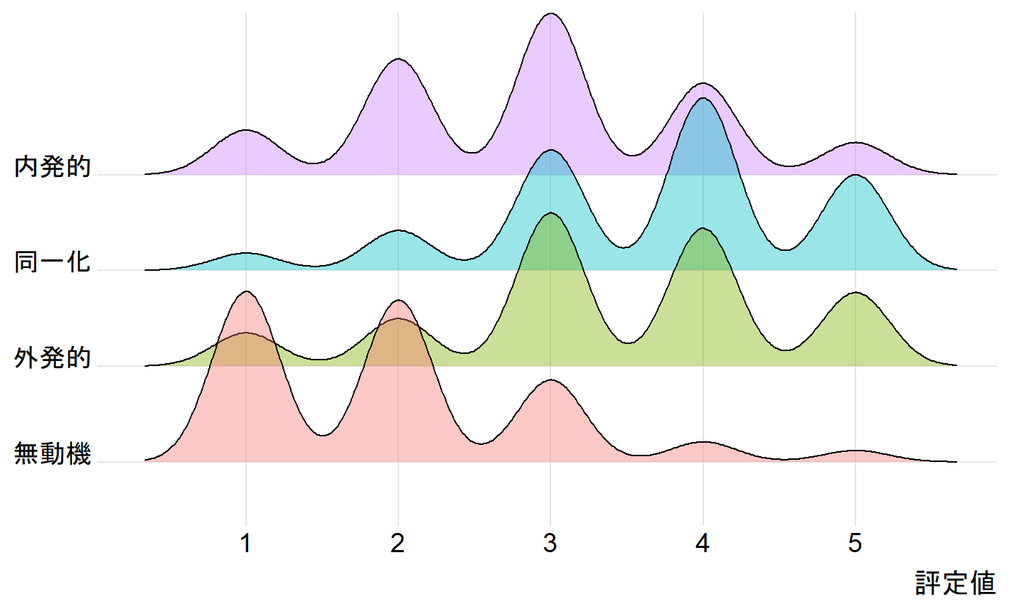

## 質問項目間の関係の分析（[心理ネットワーク分析](https://qiita.com/saltcooky/items/4e55d97c5e86dfb208cd)）

- ガウジアン・グラフィカルモデル
  - 変数間の関係を偏相関係数でモデル化
- エッジの解釈のしやすさのため、モデル選択を実施（正則化）

## ネットワークの可視化

- 実線：正の関係
- 点線：負の関係
- 線の太さ：関係の強さ
  - 全体のノードからの影響を考慮した時の 2 つのノード間の関係の強さ

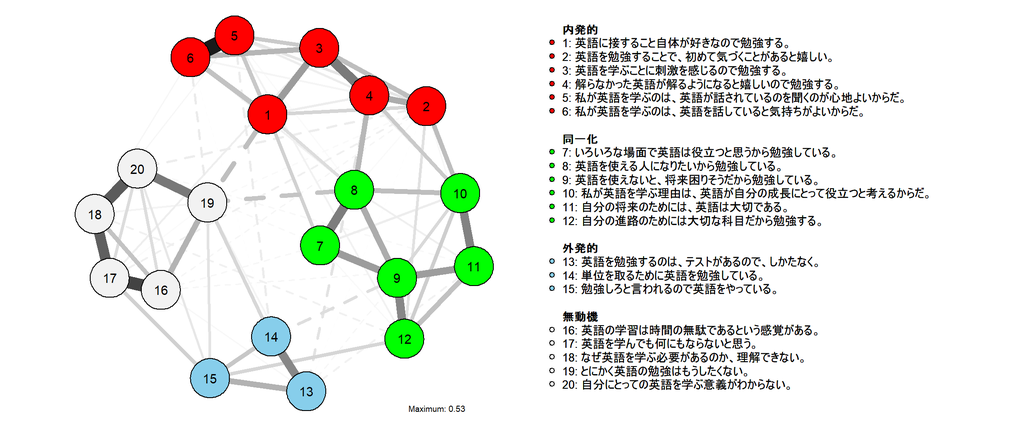

## ネットワーク分析

|  | 内発的 | 同一化 | 外発的 | 無動機 |
| --- | --- | --- | --- | --- |
| 内発的 |  |  |  |  |
| 同一化 | 0.62 |  |  |  |
| 外発的 | -0.42 | -0.37 |  |  |
| 無動機 | -0.28 | -0.37 | 0.46 |  |
| Computed correlation used pearson-method with listwise-deletion. |  |  |  |  |

### 想定とは逆の相関関係

- 内発的と無動機の項目に正の相関（項目3と17、5と18、6と18）
- 同一化と外発的の項目に正の相関（項目12と15）

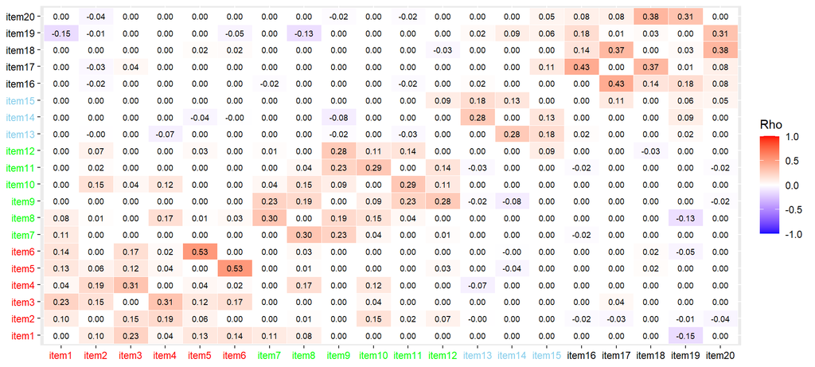

## 議論（１）

### R.Q. 1：提案された質問紙の適切性の再検討（Agawa & Takeuchi, 2016）

- 抽出された因子数と因子構造がおおむね一致
- 一部の質問紙項目には想定とは逆の関係
  - 項目レベルでみると、再検討が必要な項目もある
  - 統制の所在が外より。12は同一化ではなく、外発的？
    - 12（自分の進路のためには大切な科目だから勉強する。）
    - 15（勉強しろと言われるので英語をやっている。）

## 議論（２）

### R.Q. 2：学習者の動機づけの傾向はどうか

- 内発的よりも外発的に動機付けられている傾向にある。
- 英語力を伸ばすには継続的な学習が必要
  - 無動機と負の相関を見せた内発的動機付けを伸ばす必要
    - 動機づけと英語成績との相関あり（e.g., Alamer & Alrabai, 2023）

## 今後の展望

- 15回終了時に再度質問紙調査を実施
  - 今回のデータとの差を比較
- 英語テストの成績の伸びと動機付けの関係を分析

## 参考文献

- Alamer, A., & Alrabai, F. (2023). The causal relationship between learner motivation and language achievement: New dynamic perspective. *Applied Linguistics, 44*(1), 148–168. https://doi.org/10.1093/applin/amac035
- Agawa, T., & Takeuchi, O. (2016). A new questionnaire to assess Japanese EFL learners’ motivation: Development and validation. *ARELE: Annual Review of English Language Education in Japan, 27*, 1–16. https://doi.org/10.20581/arele.27.0_1
- Agawa, T., & Takeuchi, O. (2017). Examining the validation of a newly developed motivation questionnaire: Applying self-determination theory in the Japanese university EFL context. *JACET Journal, 61*, 1–21. https://doi.org/10.32234/jacetjournal.61.0_1
- Deci, E. L., & Ryan, R. M. (2008). Facilitating optimal motivation and psychological well-being across life’s domains. *Canadian Psychology, 49*(1), 14–23. https://psycnet.apa.org/doi/10.1037/0708-5591.49.1.14
- Deci, E. L., & Ryan, R. M. (2011). *Self-determination theory*. In P. A, M. Van Lange, A. W. Kruglanski, & E. T. Higgins, (Eds.), Handbook of theories of social psychology (Volume 1., pp.416-433). SAGE. https://doi.org/10.4135/9781446249215
- Deci, E. L., & Ryan, R. M. (2017). *Self-determination theory: Basic psychological needs in motivation, development, and wellness*. https://psycnet.apa.org/doi/10.1521/978.14625/28806
- 廣森友人 (2006). 外国語学習者の動機づけを高める理論と実践. 多賀出版.
- Saito, K., & Dewaele, J-M., & Hanzawa, K. (2017). A longitudinal investigation of the relationship between motivation and late second language speech learning in classroom settings. *Language and Speech, 60*(4), 614–632. https://psycnet.apa.org/doi/10.1177/0023830916687793
- Wang, M., Alavi, M., & Izadpanah, S. (2023). The impact of jigsaw cooperative learning on academic motivation, academic hardiness, and self-efficacy of English foreign language learners. *Learning and Motivation, 84*, 101940. https://doi.org/10.1016/j.lmot.2023.101940

## 第一著者の連絡先

### 寺井 雅人（Masato Terai）

- 愛知工科大学＠蒲郡市
- gmail: terai.research@gmail.com
- X（旧twitter）: [@uniquefreshman](https://twitter.com/uniquefreshman)

## スライドの最後です